# vinc_eda

Vincent

9/28/2019

## Preparation

```
## Observations: 175
## Variables: 16
## $ asx                      <dbl> 4107, 4173, 4110, 3983, 4106, 4278, 438…
## $ oecd_li                  <dbl> 100.21160, 100.14570, 100.06870, 100.01…
## $ abs_imports              <dbl> 11154780, 11123461, 12699350, 12569908,…
## $ abs_exports              <dbl> 9232638, 9503409, 10451659, 11566650, 1…
## $ gold_price_london_fixing <dbl> 438.00, 423.80, 436.55, 427.50, 433.20,…
## $ unemployment             <dbl> 5.056507, 5.660385, 5.796897, 5.503269,…
## $ rba_cash_rate            <dbl> 5.25, 5.25, 5.50, 5.50, 5.50, 5.50, 5.5…
## $ yearly_inflation         <dbl> 2.5, 2.5, 2.5, 2.4, 2.4, 2.4, 2.5, 2.5,…
## $ quarterly_inflation      <dbl> 1.0, 1.0, 1.0, 0.5, 0.5, 0.5, 0.6, 0.6,…
## $ exchange_rate            <dbl> 0.7744, 0.7905, 0.7719, 0.7811, 0.7557,…
## $ djia                     <dbl> 10490, 10766, 10504, 10193, 10467, 1027…
## $ pe_ratio                 <dbl> 17.0, 15.1, 14.9, 14.3, 14.3, 15.2, 15.…
## $ dividend                 <dbl> 3.6, 3.8, 3.9, 4.0, 4.0, 3.8, 3.7, 3.4,…
## $ iron                     <dbl> 28, 28, 28, 28, 28, 28, 28, 28, 28, 28,…
## $ oil                      <dbl> 47, 48, 54, 53, 50, 56, 59, 65, 66, 62,…
## $ Date                     <date> 2005-01-01, 2005-02-01, 2005-03-01, 20…
```

After mungling and merging data, we have 15 variables and 175 observations. It is the 175 months ranging from 2005 to 2019.

## Check missing data

[output not shown]

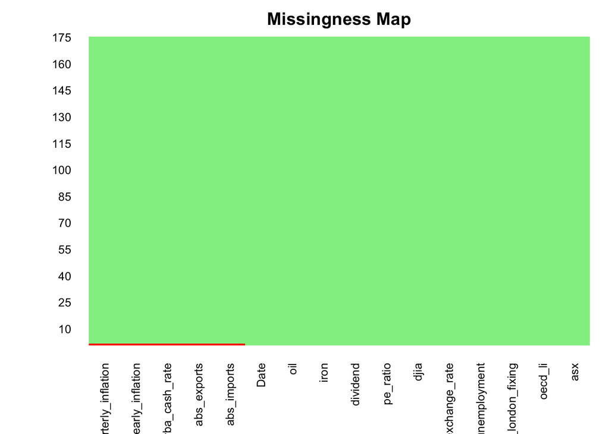

## Remove missing values

```
## Observations: 174
## Variables: 16
## $ asx                      <dbl> 4107, 4173, 4110, 3983, 4106, 4278, 438…
## $ oecd_li                  <dbl> 100.21160, 100.14570, 100.06870, 100.01…
## $ abs_imports              <dbl> 11154780, 11123461, 12699350, 12569908,…
## $ abs_exports              <dbl> 9232638, 9503409, 10451659, 11566650, 1…
## $ gold_price_london_fixing <dbl> 438.00, 423.80, 436.55, 427.50, 433.20,…
## $ unemployment             <dbl> 5.056507, 5.660385, 5.796897, 5.503269,…
## $ rba_cash_rate            <dbl> 5.25, 5.25, 5.50, 5.50, 5.50, 5.50, 5.5…
## $ yearly_inflation         <dbl> 2.5, 2.5, 2.5, 2.4, 2.4, 2.4, 2.5, 2.5,…
## $ quarterly_inflation      <dbl> 1.0, 1.0, 1.0, 0.5, 0.5, 0.5, 0.6, 0.6,…
## $ exchange_rate            <dbl> 0.7744, 0.7905, 0.7719, 0.7811, 0.7557,…
## $ djia                     <dbl> 10490, 10766, 10504, 10193, 10467, 1027…
## $ pe_ratio                 <dbl> 17.0, 15.1, 14.9, 14.3, 14.3, 15.2, 15.…
## $ dividend                 <dbl> 3.6, 3.8, 3.9, 4.0, 4.0, 3.8, 3.7, 3.4,…
## $ iron                     <dbl> 28, 28, 28, 28, 28, 28, 28, 28, 28, 28,…
## $ oil                      <dbl> 47, 48, 54, 53, 50, 56, 59, 65, 66, 62,…
## $ Date                     <date> 2005-01-01, 2005-02-01, 2005-03-01, 20…
```

After removing of missing values, one line of data is cut off. Now we have 15 variables with 174 observations.

## Feature engineering data

```
## # A tibble: 6 x 2
##     asx direction
##   <dbl> <fct>
## 1  4107 0
## 2  4173 1
## 3  4110 0
## 4  3983 0
## 5  4106 1
## 6  4278 1
```

## Visualise data

Starting with histogram could provide us the indication of distribution of some variables

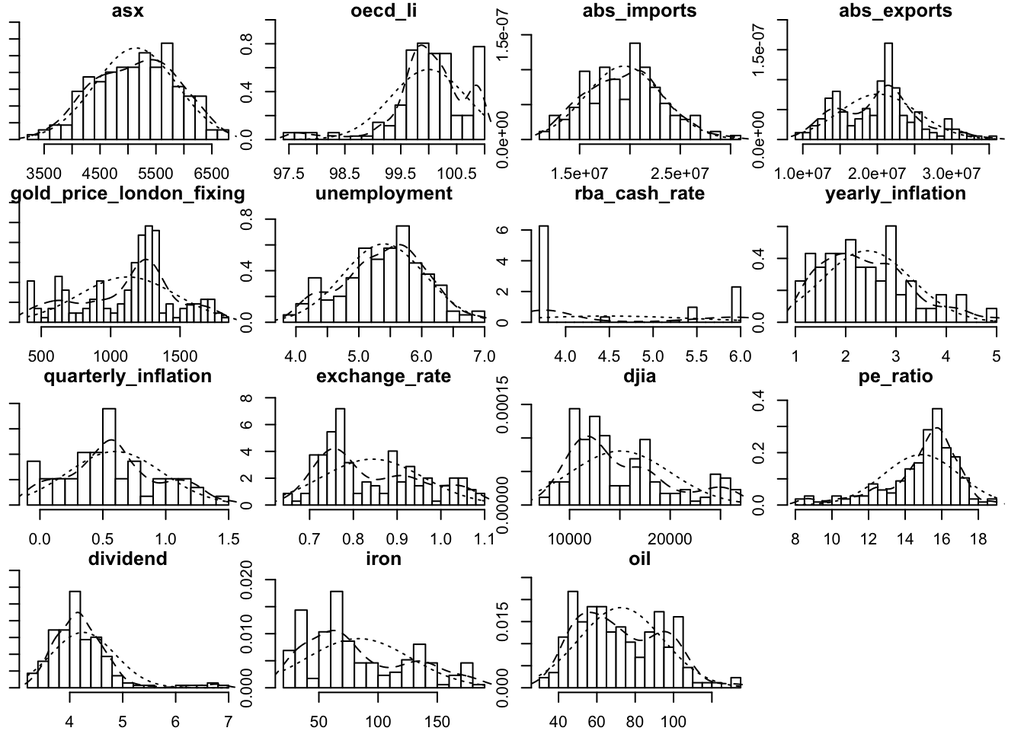

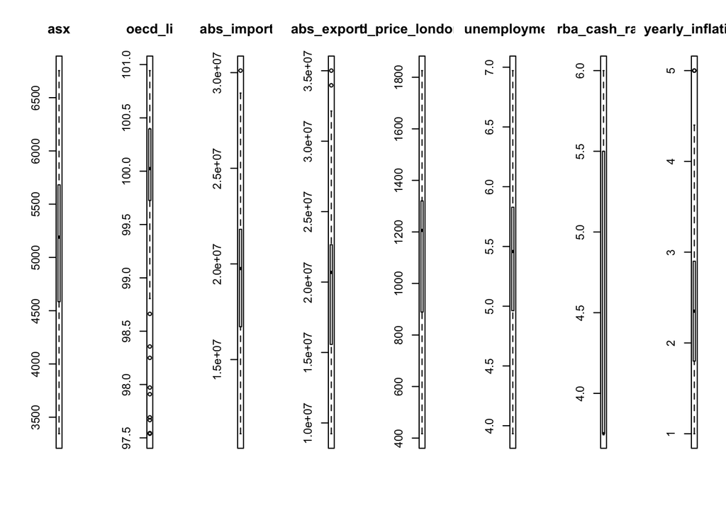

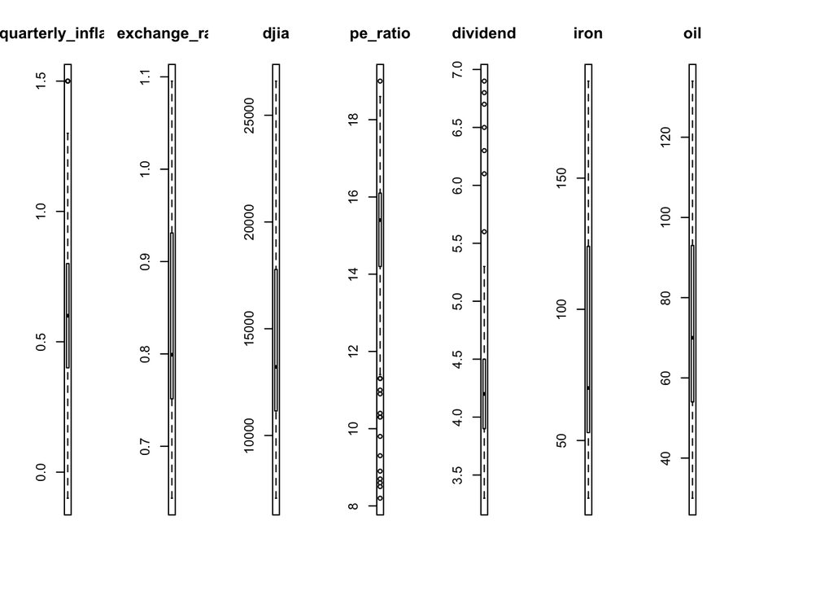

Distribution can also be seen by box plot. By this plot, oecd_li, pe_ratio and divident are having few outliers while rba_cash_ra and iron are quite distributed.

Now, we plot the correlation between each pair of numeric variables to give an idea of which variables change together.

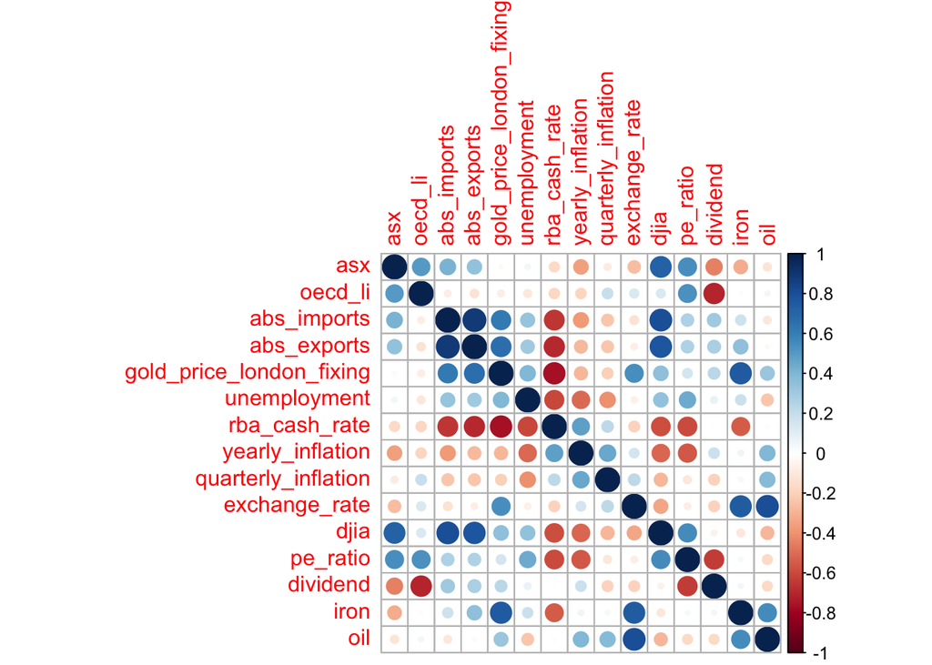

The correlation matrix is used where blue represents positive correlation and red negative and larger dot the larger correlation. In this report, we focus on the correlation between asx and other variables. On this plot, asx seems to have postive correlation with djia, pe_ratio, oecd_li, abs_imports and abs_exports as well as negative correlation with dividend, yearly_inflation, iron, exchange_rate.

Given those high correlation variables, we put those into scatter plots matrix with direction up/down as an indicator, blue for up and red for down.

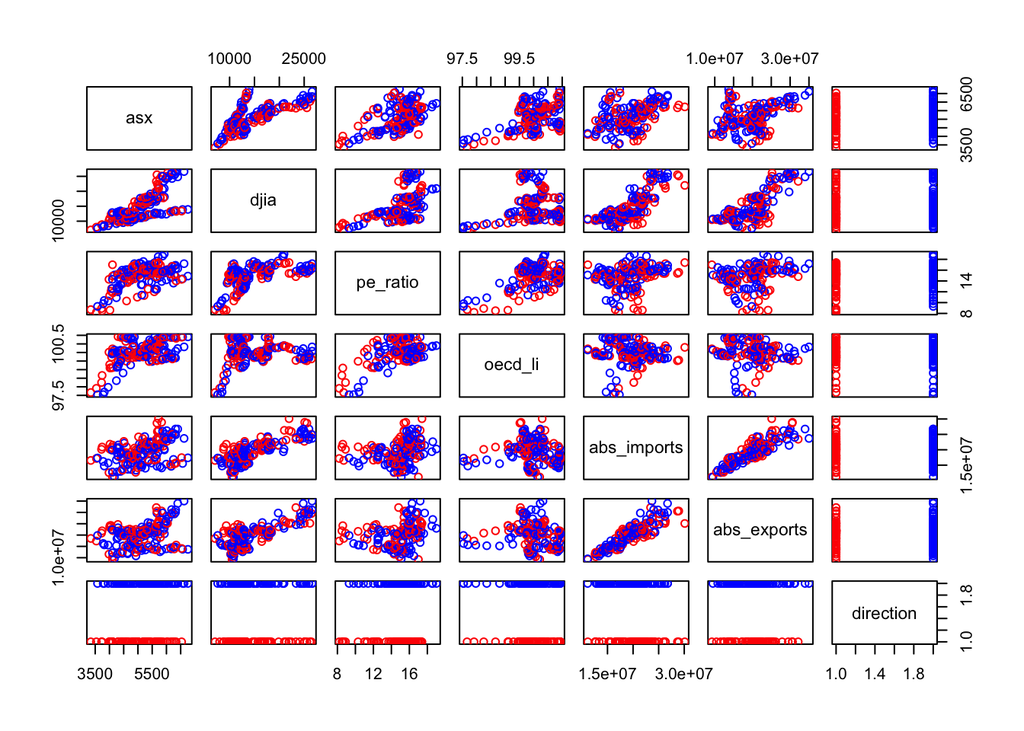

The djia, pe_ratio could give some signals of positive correlation but not too strong here.

Now we take the further step to view the distribution of each variable broken down into direction. Below plot presents to us the distribution of up and down are quite similar in all variables. There are slight differences of up and down at iron, oil, quarterly_inflation and abs_exports but it is still hard to predict something here. In general, it is hard to predict up and down if using only one or two variables.

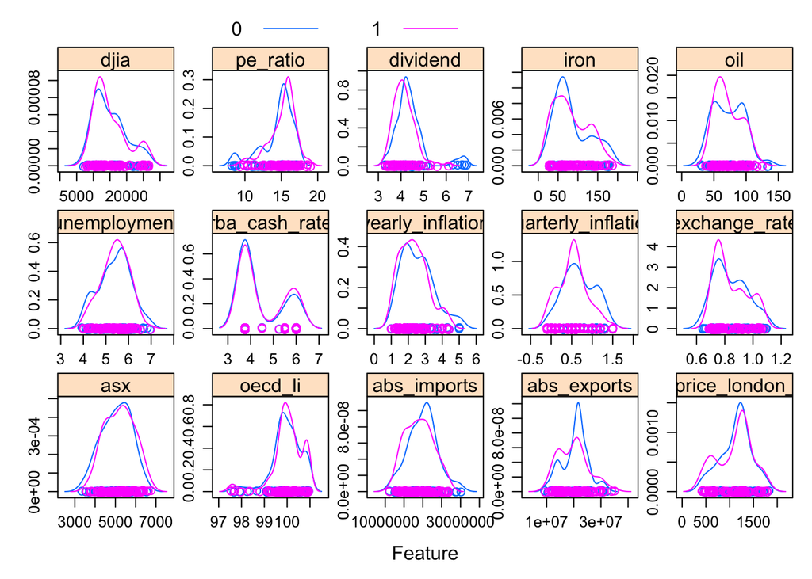